# Project 2

#### Part A.

In part A, we would iterate through the Matrix Linspace to solve Newton's method for the Kepler equation for each $t$. Each solve allowed 6 iterations, did not print output information to the screen and was set to a tolerance of $10^{-5}$.  
The initial guess for each $\omega$ was the previous $t$, with $0$ being the very first $\omega$. This was easily achieved using the provided matrix class and declaring all variables, as well as initializing the Linspace.  
The for loop iterated over the values of t and solved the newton equation for that t and stored it in a vector, which would be used later in part B. The value of $\omega$ was reset at each iteration.

```python
int main(){
	//declare function and derivative
	fcn f;
	derfcn df;

	//declare tolerance, iterations coutn and iterates
	const double tolerance = pow(10.0,-5.0);
	const bool show_iterates = false;
	const int iterations = 6;

	//declare a, b and derive epsilon
	const double a = 2.0;
	const double b = 1.25;
	double epsilon = sqrt(1-(b*b)/(a*a));

	//declare the initial w and the Linspace of t
	double w = 0.0;
	Matrix ts = Linspace(0,10,1,(size_t)10000);

	//declare a vector of double to store results from the newton method
	vector<double> ws;

	//loop over all values of t, reset t in the function class and push the
    //result of Newton's method to the vector of results. Reset w
	for( int i =0 ; i<ts.Cols();i++){
		f.setT(ts[0][i]);
		ws.push_back(newton(f,df,w,  iterations, tolerance,show_iterates));
		w = ts[0][i];
	}
```

#### Part B.

In part B, we were to use the computed radial position to compute the cartesian Coordinates for an object at angle $\omega$ using the formula
$$r(\omega) = \frac{ab} { \sqrt{(bcos(\omega))^2 + (asin(\omega)^2}}$$
with $x(t) = rcos(\omega)$ and $y(t) = rsin(\omega)$. This was done by iterating over the values of $\omega$ from part A.

```python
	//convert x and y coordinates to radial
	vector<double> cartesianxs;
	vector<double> cartesianys;

	double r;

	//iterate over all values of w, compute r and the cartesian coordinates and
	for( int i = 0 ; i < ws.size(); i++){

		r = (a*b) / (sqrt( pow(b * cos(ws[i]),2) + pow(a * sin(ws[i]),2) ));


		cartesianxs.push_back(r*cos(ws[i]));
		cartesianys.push_back(r*sin(ws[i]));

	}
```

#### Part C.

For the last part we were to save our results in a Matrix and write to a file. This was done easily using the provided functionality of the Matrix class.

The first plot required from the above is $x(t)$ vs. $t$.

```python
%pylab inline
t = loadtxt('t.txt')
x = loadtxt('x.txt')
y = loadtxt('y.txt')
```

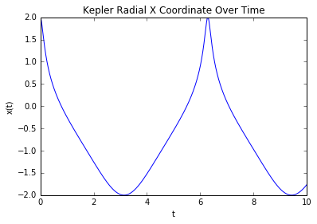

```python
plot(t,x)
xlabel('t')
ylabel('x(t)')
title('Kepler Radial X Coordinate Over Time')
```

These are the expected results for x, since we can see that it has a period of 6 and looks like a sinusoid in shape, because it repeats. Since we used $r*cos(\omega)$ to get this x-coordinate, we are to expect this specific behaviour, as we are dealing with radial positions, since $\omega$ is an angle of the elliptical orbit of the Kepler function.

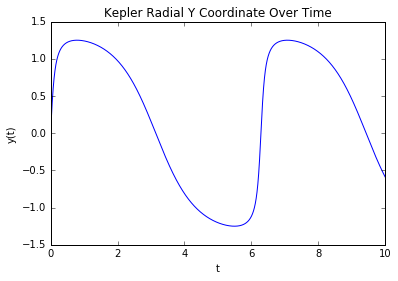

```python
plot(t,y)
xlabel('t')
ylabel('y(t)')
title('Kepler Radial Y Coordinate Over Time')
```

Similarly, y gives expected values and has the same period as x. The same behaviour is observed, since we are again dealing with radial positions, since $\omega$ is an angle of the elliptical orbit of the Kepler function.

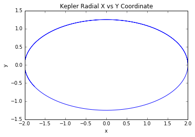

```python
plot(x,y)
xlabel('x')
ylabel('y')
title('Kepler Radial X vs Y Coordinate')
```

The X vs Y plot shows us that for each value of x there are two corresponding values of y, that have the same magnitude, but different sign. This is why we get an oval as a result from the plot. We recreate the original elliptical orbit that the Kepler function would create in the given time interval that we specified in our input. This is to represent the Kepler function on the time interval from $[0,10]$ and initial $\omega$ of 0.0.

### 4. Makefile

The following Makefile was used to ease the compilation of all the files in the project.

```python
# compiler & flags
CXX = g++
CXXFLAGS = -O -std=c++11
#CXXFLAGS = -O0 -g -std=c++11

# makefile targets
all : vandermonde.exe test_newton.exe kepler.exe

vandermonde.exe : vandermonde.cpp vandermonde.o
	$(CXX) $(CXXFLAGS) $^ -o $@

test_newton.exe : test_newton.cpp matrix.o
	$(CXX) $(CXXFLAGS) $^ -o $@

kepler.exe : kepler.cpp matrix.o
	$(CXX) $(CXXFLAGS) $^ -o $@

vandermonde.o : matrix.cpp vandermonde.cpp
	$(CXX) $(CXXFLAGS) -c $< -o $@

test_newton.o : matrix.cpp test_newton.cpp
	$(CXX) $(CXXFLAGS) -c $< -o $@

kepler.o : matrix.cpp kepler.cpp
	$(CXX) $(CXXFLAGS) -c $< -o $@

clean :
	\rm -f *.o *.out a_data *.txt

realclean : clean
	\rm -f *.exe *~
```